# Reproducible Research: Peer Assessment 1

Solution developed as part of the Reproducible Research course of the Data Science Specialization from Coursera.

## Loading and preprocessing the data

1. Load the data (i.e. read.csv())

```r
library(data.table)
library(dplyr)
library(ggplot2)
unzip("activity.zip")
raw <- read.table("activity.csv", sep = ",", header = TRUE, na.strings = "NA")
```

2. Process/transform the data (if necessary) into a format suitable for your analysis

```r
data <- raw
data$date <- as.Date(data$date, format = "%Y-%m-%d")
data <- data[complete.cases(data),]
data <- data.table(data)
summary(data)
```

```
##      steps             date               interval
##  Min.   :  0.00   Min.   :2012-10-02   Min.   :   0.0
##  1st Qu.:  0.00   1st Qu.:2012-10-16   1st Qu.: 588.8
##  Median :  0.00   Median :2012-10-29   Median :1177.5
##  Mean   : 37.38   Mean   :2012-10-30   Mean   :1177.5
##  3rd Qu.: 12.00   3rd Qu.:2012-11-16   3rd Qu.:1766.2
##  Max.   :806.00   Max.   :2012-11-29   Max.   :2355.0
```

```r
head(data)
```

```
##    steps       date interval
## 1:     0 2012-10-02        0
## 2:     0 2012-10-02        5
## 3:     0 2012-10-02       10
## 4:     0 2012-10-02       15
## 5:     0 2012-10-02       20
## 6:     0 2012-10-02       25
```

## What is mean total number of steps taken per day?

1. Calculate the total number of steps taken per day

```r
groupedByDate <- group_by(data, date)
totalStepsPerDay <- summarise(groupedByDate, totalSteps = sum(steps))
summary(totalStepsPerDay)
```

```
##       date              totalSteps
##  Min.   :2012-10-02   Min.   :   41
##  1st Qu.:2012-10-16   1st Qu.: 8841
##  Median :2012-10-29   Median :10765
##  Mean   :2012-10-30   Mean   :10766
##  3rd Qu.:2012-11-16   3rd Qu.:13294
##  Max.   :2012-11-29   Max.   :21194
```

2. Make a histogram of the total number of steps taken each day

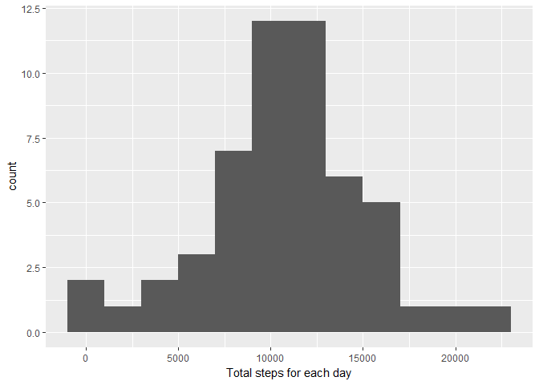

```r
ggplot(totalStepsPerDay, aes(x = totalSteps)) +
  geom_histogram(stat="bin", binwidth=2000) +
  xlab("Total steps for each day")
```

3. Calculate and report the mean and median of the total number of steps taken per day

```r
mean(totalStepsPerDay$totalSteps)
```

```
## [1] 10766.19
```

```r
median(totalStepsPerDay$totalSteps)
```

```
## [1] 10765
```

## What is the average daily activity pattern?

1. Make a time series plot (i.e. type = “l”) of the 5-minute interval (x-axis) and the average number of steps taken, averaged across all days (y-axis)

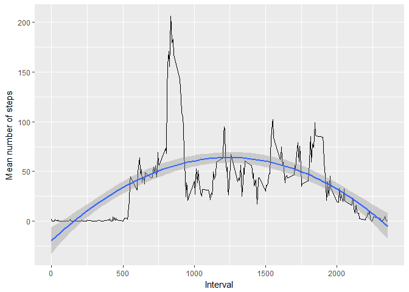

```r
groupedByInterval <- group_by(data, interval)
meanStepsPerInterval <- summarise(groupedByInterval, meanSteps = mean(steps))

ggplot(meanStepsPerInterval, aes(x = interval, y = meanSteps)) +
  geom_line() +
  geom_smooth(method = "lm", formula = y ~ splines::bs(x, 3)) +
  xlab("Interval") +
  ylab("Mean number of steps")
```

2. Which 5-minute interval, on average across all the days in the dataset, contains the maximum number of steps?

```r
meanStepsPerInterval$interval[which.max(meanStepsPerInterval$meanSteps)]
```

```
## [1] 835
```